# Forecasting the Sales of a Furniture store

We are using Superstore sales data for furniture sales between 2014 to 2017 and apply a simple model to forecast for 2018

## Content

1. **Import packages**
2. **Load data**
3. **Data preparation**
   - 3.1 - Dimensions of Dataset
   - 3.2 - Statistical Summary
   - 3.3 - Checking Data Type and Missing Values
   - 3.4 - Indexing with Date
4. **Time Series Analysis**
   - 4.1 - Visualizing data
   - 4.2 - Sampling
   - 4.3 - Checking Stationarity
   - 4.4 - Decomposing
5. **Time Series Forcasting using ARIMA**
   - 5.1 - Parameter Selection
   - 5.2 - Fitting the ARIMA model
   - 5.3 - Validating Forecasts
   - 5.4 - Calculating MSE and RMSE
   - 5.5 - Visualizing the Forecast
6. **Conclusion**

# 1. Import Packages

```python
import itertools
import numpy as np
import matplotlib.pyplot as plt
import pandas as pd
import statsmodels.api as sm
import seaborn as sns
sns.set()
```

# 2. Load Data

|  | **Load the data using read_csv() function from pandas** |
| --- | --- |

```python
furniture = pd.read_csv("Super_Store.csv",sep=",", encoding='cp1252')
furniture.head()
```

|  | Row ID | Order ID | Order Date | Ship Date | Ship Mode | Customer ID | Customer Name | Segment | Country | City | ... | Postal Code | Region | Product ID | Category | Sub-Category | Product Name | Sales | Quantity | Discount | Profit |
| --- | --- | --- | --- | --- | --- | --- | --- | --- | --- | --- | --- | --- | --- | --- | --- | --- | --- | --- | --- | --- | --- |
| 0 | 1 | CA-2016-152156 | 11/8/2016 | 11/11/2016 | Second Class | CG-12520 | Claire Gute | Consumer | United States | Henderson | ... | 42420 | South | FUR-BO-10001798 | Furniture | Bookcases | Bush Somerset Collection Bookcase | 261.9600 | 2 | 0.00 | 41.9136 |
| 1 | 2 | CA-2016-152156 | 11/8/2016 | 11/11/2016 | Second Class | CG-12520 | Claire Gute | Consumer | United States | Henderson | ... | 42420 | South | FUR-CH-10000454 | Furniture | Chairs | Hon Deluxe Fabric Upholstered Stacking Chairs,... | 731.9400 | 3 | 0.00 | 219.5820 |
| 2 | 4 | US-2015-108966 | 10/11/2015 | 10/18/2015 | Standard Class | SO-20335 | Sean O'Donnell | Consumer | United States | Fort Lauderdale | ... | 33311 | South | FUR-TA-10000577 | Furniture | Tables | Bretford CR4500 Series Slim Rectangular Table | 957.5775 | 5 | 0.45 | -383.0310 |
| 3 | 6 | CA-2014-115812 | 6/9/2014 | 6/14/2014 | Standard Class | BH-11710 | Brosina Hoffman | Consumer | United States | Los Angeles | ... | 90032 | West | FUR-FU-10001487 | Furniture | Furnishings | Eldon Expressions Wood and Plastic Desk Access... | 48.8600 | 7 | 0.00 | 14.1694 |
| 4 | 11 | CA-2014-115812 | 6/9/2014 | 6/14/2014 | Standard Class | BH-11710 | Brosina Hoffman | Consumer | United States | Los Angeles | ... | 90032 | West | FUR-TA-10001539 | Furniture | Tables | Chromcraft Rectangular Conference Tables | 1706.1840 | 9 | 0.20 | 85.3092 |

5 rows × 21 columns

# 3. Data Preparation

[figure not shown]

# 3.1 Dimensions of Dataset

We get a quick idea of how many instances (rows) and how many attributes (columns) the data contains with the shape property.

```python
# Checking structure of the data
furniture.shape
```

```
(2121, 21)
```

# 3.2 Statistical Summary

Here we take a look at the summary of each attribute.

This includes the count, mean, the min and max values as well as percentiles.

```python
furniture.describe()
```

|  | Row ID | Postal Code | Sales | Quantity | Discount | Profit |
| --- | --- | --- | --- | --- | --- | --- |
| count | 2121.000000 | 2121.000000 | 2121.000000 | 2121.000000 | 2121.000000 | 2121.000000 |
| mean | 5041.643564 | 55726.556341 | 349.834887 | 3.785007 | 0.173923 | 8.699327 |
| std | 2885.740258 | 32261.888225 | 503.179145 | 2.251620 | 0.181547 | 136.049246 |
| min | 1.000000 | 1040.000000 | 1.892000 | 1.000000 | 0.000000 | -1862.312400 |
| 25% | 2568.000000 | 22801.000000 | 47.040000 | 2.000000 | 0.000000 | -12.849000 |
| 50% | 5145.000000 | 60505.000000 | 182.220000 | 3.000000 | 0.200000 | 7.774800 |
| 75% | 7534.000000 | 90032.000000 | 435.168000 | 5.000000 | 0.300000 | 33.726600 |
| max | 9991.000000 | 99301.000000 | 4416.174000 | 14.000000 | 0.700000 | 1013.127000 |

## 3.3 Checking for Missing Values

```python
# summary of the data
furniture.info()
```

```
<class 'pandas.core.frame.DataFrame'>
RangeIndex: 2121 entries, 0 to 2120
Data columns (total 21 columns):
 #   Column         Non-Null Count  Dtype
---  ------         --------------  -----
 0   Row ID         2121 non-null   int64
 1   Order ID       2121 non-null   object
 2   Order Date     2121 non-null   object
 3   Ship Date      2121 non-null   object
 4   Ship Mode      2121 non-null   object
 5   Customer ID    2121 non-null   object
 6   Customer Name  2121 non-null   object
 7   Segment        2121 non-null   object
 8   Country        2121 non-null   object
 9   City           2121 non-null   object
 10  State          2121 non-null   object
 11  Postal Code    2121 non-null   int64
 12  Region         2121 non-null   object
 13  Product ID     2121 non-null   object
 14  Category       2121 non-null   object
 15  Sub-Category   2121 non-null   object
 16  Product Name   2121 non-null   object
 17  Sales          2121 non-null   float64
 18  Quantity       2121 non-null   int64
 19  Discount       2121 non-null   float64
 20  Profit         2121 non-null   float64
dtypes: float64(3), int64(3), object(15)
memory usage: 348.1+ KB
```

Checking the stock time stamp

```python
furniture['Order Date'].min(), furniture['Order Date'].max()
```

```
('1/1/2017', '9/9/2017')
```

We remove the columns that we do not need as well as check missing values

```python
cols = ['Row ID', 'Order ID', 'Ship Date', 'Ship Mode', 'Customer ID', 'Customer Name', 'Segment', 'Country', 'City', 'State', 'Postal Code', 'Region', 'Product ID', 'Category', 'Sub-Category', 'Product Name', 'Quantity', 'Discount', 'Profit']
furniture.drop(cols, axis=1, inplace=True)
furniture = furniture.sort_values('Order Date')
```

Checking for null values

```python
furniture.isnull().sum()
```

```
Order Date    0
Sales         0
dtype: int64
```

|  | **There are no missing values** |
| --- | --- |

## 3.5 Indexing with Date

Aggregate price by date

```python
furniture = furniture.groupby('Order Date')['Sales'].sum().reset_index()
```

```python
furniture['Order Date'] = pd.to_datetime(furniture['Order Date'])
furniture.set_index('Order Date', inplace=True)
furniture.index
```

```
DatetimeIndex(['2017-01-01', '2014-01-10', '2015-01-10', '2016-01-10',
               '2014-01-11', '2016-01-11', '2017-01-12', '2014-01-13',
               '2015-01-13', '2017-01-13',
               ...
               '2014-09-07', '2015-09-07', '2017-09-07', '2014-09-08',
               '2015-09-08', '2016-09-08', '2017-09-08', '2014-09-09',
               '2016-09-09', '2017-09-09'],
              dtype='datetime64[ns]', name='Order Date', length=889, freq=None)
```

```python
furniture.head()
```

| Order Date | Sales |
| --- | --- |
| 2017-01-01 | 975.490 |
| 2014-01-10 | 51.940 |
| 2015-01-10 | 1018.104 |
| 2016-01-10 | 104.770 |
| 2014-01-11 | 9.940 |

[output not shown]

# 4. Time Series Analysis

|  | Now we analysis Time series data to do so we need to perform following steps 1. Visualizing Data 2. Sampling 3. Checking Stationarity 4. Decomposing |
| --- | --- |

## 4.1 Visualizing data

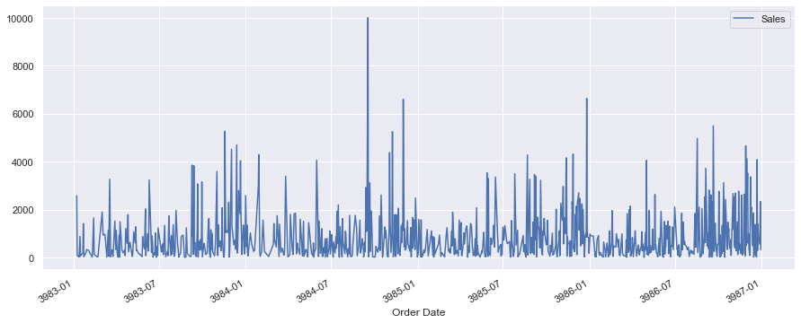

```python
furniture.plot(figsize=(15, 6))
plt.show()
```

## 4.2 Sampling

```python
y = furniture['Sales'].resample('MS').mean()
```

```python
y
```

```
Order Date
2014-01-01     480.194231
2014-02-01     367.931600
2014-03-01     857.291529
2014-04-01     567.488357
2014-05-01     432.049187
2014-06-01     695.059242
2014-07-01     601.169500
2014-08-01     457.521656
2014-09-01     992.353367
2014-10-01     769.015437
2014-11-01     980.221486
2014-12-01    1532.298325
2015-01-01     978.328467
2015-02-01     522.395667
2015-03-01     781.236437
2015-04-01     805.822962
2015-05-01     624.996700
2015-06-01     428.565500
2015-07-01     719.706316
2015-08-01     602.412013
2015-09-01    1382.790684
2015-10-01     632.980184
2015-11-01    1286.701354
2015-12-01    1049.355418
2016-01-01     508.182867
2016-02-01     356.868273
2016-03-01     609.575810
2016-04-01     695.373158
2016-05-01     687.265227
2016-06-01     816.910750
2016-07-01     768.736412
2016-08-01     734.307782
2016-09-01    1135.953371
2016-10-01     624.872474
2016-11-01    1271.345152
2016-12-01    1410.719808
2017-01-01     397.602133
2017-02-01     528.179800
2017-03-01     544.672240
2017-04-01     453.297905
2017-05-01     678.302328
2017-06-01     826.460291
2017-07-01     562.524857
2017-08-01     857.881889
2017-09-01    1209.508583
2017-10-01     875.362728
2017-11-01    1277.817759
2017-12-01    1256.298672
Freq: MS, Name: Sales, dtype: float64
```

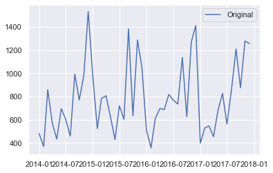

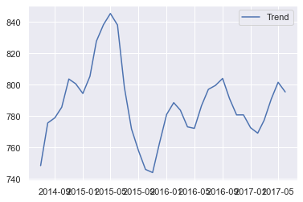

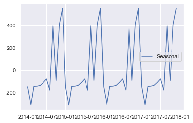

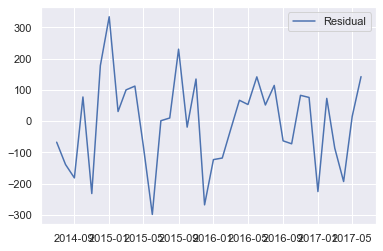

```python
from statsmodels.tsa.seasonal import seasonal_decompose
decomposition = seasonal_decompose(y)

plt.plot(y, label = 'Original')
plt.legend(loc = 'best')

trend = decomposition.trend
plt.show()
plt.plot(trend, label = 'Trend')
plt.legend(loc = 'best')

seasonal = decomposition.seasonal
plt.show()
plt.plot(seasonal, label = 'Seasonal')
plt.legend(loc = 'best')

residual = decomposition.resid
plt.show()
plt.plot(residual, label = 'Residual')
plt.legend(loc='best')
```

[output not shown]

## 4.3 Checking Stationarity

Our first step in time-series analysis should be to check whether there is any evidence of a trend or seasonal effects and, if there is, remove them. Augmented Dickey-Fuller(ADF) statistics is one of the more widely used statistical test to check whether your time series is stationary or non-stationary. It uses an autoregressive model and optimizes an information criterion across multiple different lag values.

**Null Hypothesis: The series has a unit root (value of a =1)(not stationary)**

**Alternate Hypothesis: The series has no unit root (stationary)**

```python
from statsmodels.tsa.stattools import adfuller
```

```python
from pandas import Series
from statsmodels.tsa.stattools import adfuller
#series = Series.from_csv('daily-total-female-births.csv', header=0)
result = adfuller(y)
print('ADF Statistic: %f' % result[0])
print('p-value: %f' % result[1])
print('Critical Values:')
for key, value in result[4].items():
    print('\t%s: %.3f' % (key, value))
```

```
ADF Statistic: -5.191070
p-value: 0.000009
Critical Values:
	1%: -3.621
	5%: -2.944
	10%: -2.610
```

[figure not shown]

## 4.4 Decomposing

Decomposing the time series into three distinct components: trend, seasonality, and noise.

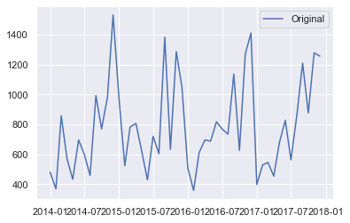

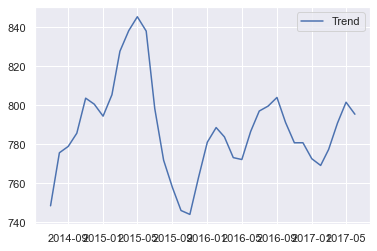

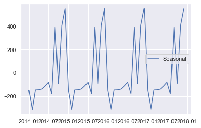

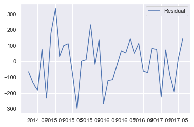

```python
from statsmodels.tsa.seasonal import seasonal_decompose
decomposition = seasonal_decompose(y)

plt.plot(y, label = 'Original')
plt.legend(loc = 'best')

trend = decomposition.trend
plt.show()
plt.plot(trend, label = 'Trend')
plt.legend(loc = 'best')

seasonal = decomposition.seasonal
plt.show()
plt.plot(seasonal, label = 'Seasonal')
plt.legend(loc = 'best')

residual = decomposition.resid
plt.show()
plt.plot(residual, label = 'Residual')
plt.legend(loc='best')
```

[output not shown]

# 5. Time Series Forcasting using ARIMA

|  | **We will use ARIMA for forecasting our time series. ARIMA is also denoted as ARIMA(p,d,q) where p,d,q accounts for seasonality, trend and noise in the time series data** |
| --- | --- |

```python
p = d = q = range(0, 2)
pdq = list(itertools.product(p, d, q))
seasonal_pdq = [(x[0], x[1], x[2], 12) for x in list(itertools.product(p, d, q))]
print('Examples of parameter combinations for Seasonal ARIMA...')
print('SARIMAX: {} x {}'.format(pdq[1], seasonal_pdq[1]))
print('SARIMAX: {} x {}'.format(pdq[1], seasonal_pdq[2]))
print('SARIMAX: {} x {}'.format(pdq[2], seasonal_pdq[3]))
print('SARIMAX: {} x {}'.format(pdq[2], seasonal_pdq[4]))
```

```
Examples of parameter combinations for Seasonal ARIMA...
SARIMAX: (0, 0, 1) x (0, 0, 1, 12)
SARIMAX: (0, 0, 1) x (0, 1, 0, 12)
SARIMAX: (0, 1, 0) x (0, 1, 1, 12)
SARIMAX: (0, 1, 0) x (1, 0, 0, 12)
```

## 5.1 Parameter Selection

|  | **We use “grid search” to find the optimal set of parameters that yields the best performance for our model** |
| --- | --- |

```python
from pylab import rcParams
for param in pdq:
    for param_seasonal in seasonal_pdq:
        try:
            mod = sm.tsa.statespace.SARIMAX(y, order=param,
seasonal_order=param_seasonal,
enforce_stationarity=False,
enforce_invertibility=False)
            results = mod.fit()
            print('ARIMA{}x{}12 - AIC:{}'.format(param, param_seasonal, results.aic))
        except:
            continue
```

```
ARIMA(0, 0, 0)x(0, 0, 0, 12)12 - AIC:769.0817523205915
```

```
ARIMA(0, 0, 0)x(0, 0, 1, 12)12 - AIC:1447.726832397048
ARIMA(0, 0, 0)x(0, 1, 0, 12)12 - AIC:477.7170130920111
ARIMA(0, 0, 0)x(0, 1, 1, 12)12 - AIC:302.2702899929862
ARIMA(0, 0, 0)x(1, 0, 0, 12)12 - AIC:497.2314433418338
```

```
ARIMA(0, 0, 0)x(1, 0, 1, 12)12 - AIC:1415.0848783349095
ARIMA(0, 0, 0)x(1, 1, 0, 12)12 - AIC:318.0047199116341
ARIMA(0, 0, 0)x(1, 1, 1, 12)12 - AIC:304.24882803672045
ARIMA(0, 0, 1)x(0, 0, 0, 12)12 - AIC:720.9252270758109
```

```
ARIMA(0, 0, 1)x(0, 0, 1, 12)12 - AIC:nan
ARIMA(0, 0, 1)x(0, 1, 0, 12)12 - AIC:466.56074298091374
ARIMA(0, 0, 1)x(0, 1, 1, 12)12 - AIC:291.6261389673032
```

```
ARIMA(0, 0, 1)x(1, 0, 0, 12)12 - AIC:499.5395703482367
ARIMA(0, 0, 1)x(1, 0, 1, 12)12 - AIC:4003.274853583938
ARIMA(0, 0, 1)x(1, 1, 0, 12)12 - AIC:319.9884876927768
ARIMA(0, 0, 1)x(1, 1, 1, 12)12 - AIC:291.87255765311346
ARIMA(0, 1, 0)x(0, 0, 0, 12)12 - AIC:677.894766843944
ARIMA(0, 1, 0)x(0, 0, 1, 12)12 - AIC:1509.8927051032151
```

```
ARIMA(0, 1, 0)x(0, 1, 0, 12)12 - AIC:486.63785672087647
ARIMA(0, 1, 0)x(0, 1, 1, 12)12 - AIC:304.96712281714747
ARIMA(0, 1, 0)x(1, 0, 0, 12)12 - AIC:497.78896630044073
```

```
ARIMA(0, 1, 0)x(1, 0, 1, 12)12 - AIC:1153.2518120805018
ARIMA(0, 1, 0)x(1, 1, 0, 12)12 - AIC:319.7714068109211
ARIMA(0, 1, 0)x(1, 1, 1, 12)12 - AIC:306.9113200215085
ARIMA(0, 1, 1)x(0, 0, 0, 12)12 - AIC:649.9056176709432
ARIMA(0, 1, 1)x(0, 0, 1, 12)12 - AIC:2941.6701576441596
ARIMA(0, 1, 1)x(0, 1, 0, 12)12 - AIC:458.87055484840903
ARIMA(0, 1, 1)x(0, 1, 1, 12)12 - AIC:279.58062317204275
ARIMA(0, 1, 1)x(1, 0, 0, 12)12 - AIC:486.18329774397955
ARIMA(0, 1, 1)x(1, 0, 1, 12)12 - AIC:2561.845836165533
ARIMA(0, 1, 1)x(1, 1, 0, 12)12 - AIC:310.75743684170345
ARIMA(0, 1, 1)x(1, 1, 1, 12)12 - AIC:281.55766215065523
ARIMA(1, 0, 0)x(0, 0, 0, 12)12 - AIC:692.1645522067712
```

```
ARIMA(1, 0, 0)x(0, 0, 1, 12)12 - AIC:1293.1259271614322
ARIMA(1, 0, 0)x(0, 1, 0, 12)12 - AIC:479.46321478521355
ARIMA(1, 0, 0)x(0, 1, 1, 12)12 - AIC:304.20776751651505
ARIMA(1, 0, 0)x(1, 0, 0, 12)12 - AIC:480.92593679353877
```

```
ARIMA(1, 0, 0)x(1, 0, 1, 12)12 - AIC:1066.762099904668
ARIMA(1, 0, 0)x(1, 1, 0, 12)12 - AIC:304.46646750656055
ARIMA(1, 0, 0)x(1, 1, 1, 12)12 - AIC:304.5842692185429
ARIMA(1, 0, 1)x(0, 0, 0, 12)12 - AIC:665.7794442578802
ARIMA(1, 0, 1)x(0, 0, 1, 12)12 - AIC:2655.1215623750822
ARIMA(1, 0, 1)x(0, 1, 0, 12)12 - AIC:468.3637985658863
ARIMA(1, 0, 1)x(0, 1, 1, 12)12 - AIC:293.3422194967692
ARIMA(1, 0, 1)x(1, 0, 0, 12)12 - AIC:482.57633240703694
ARIMA(1, 0, 1)x(1, 0, 1, 12)12 - AIC:3120.3234837655828
ARIMA(1, 0, 1)x(1, 1, 0, 12)12 - AIC:304.3753786424706
ARIMA(1, 0, 1)x(1, 1, 1, 12)12 - AIC:293.751318829485
ARIMA(1, 1, 0)x(0, 0, 0, 12)12 - AIC:671.2513547541903
```

```
ARIMA(1, 1, 0)x(0, 0, 1, 12)12 - AIC:906.2819318994635
ARIMA(1, 1, 0)x(0, 1, 0, 12)12 - AIC:479.2003422281135
ARIMA(1, 1, 0)x(0, 1, 1, 12)12 - AIC:300.21306116144206
ARIMA(1, 1, 0)x(1, 0, 0, 12)12 - AIC:475.34036585859485
```

```
ARIMA(1, 1, 0)x(1, 0, 1, 12)12 - AIC:1008.7917214317157
ARIMA(1, 1, 0)x(1, 1, 0, 12)12 - AIC:300.62709013121884
ARIMA(1, 1, 0)x(1, 1, 1, 12)12 - AIC:302.3264992593174
ARIMA(1, 1, 1)x(0, 0, 0, 12)12 - AIC:649.0318019776372
ARIMA(1, 1, 1)x(0, 0, 1, 12)12 - AIC:3041.9935916948953
ARIMA(1, 1, 1)x(0, 1, 0, 12)12 - AIC:460.47626873976486
ARIMA(1, 1, 1)x(0, 1, 1, 12)12 - AIC:281.3873006930173
ARIMA(1, 1, 1)x(1, 0, 0, 12)12 - AIC:469.5250354658613
```

```
ARIMA(1, 1, 1)x(1, 0, 1, 12)12 - AIC:2563.690843692009
ARIMA(1, 1, 1)x(1, 1, 0, 12)12 - AIC:297.7875439869055
ARIMA(1, 1, 1)x(1, 1, 1, 12)12 - AIC:283.3661015075786
```

[output not shown]

## 5.2 Fitting the ARIMA model

```python
mod = sm.tsa.statespace.SARIMAX(y,
                                order=(1, 1, 1),
                                seasonal_order=(1, 1, 1, 12),
                                enforce_stationarity=False,
                                enforce_invertibility=False)
results = mod.fit()
print(results.summary().tables[1])
```

```
==============================================================================
                 coef    std err          z      P>|z|      [0.025      0.975]
------------------------------------------------------------------------------
ar.L1         -0.0949      0.313     -0.303      0.762      -0.708       0.518
ma.L1         -1.0000      0.415     -2.409      0.016      -1.813      -0.187
ar.S.L12      -0.0036      0.422     -0.008      0.993      -0.831       0.824
ma.S.L12      -0.3011      0.500     -0.602      0.547      -1.281       0.679
sigma2      2.476e+04   1.68e-05   1.48e+09      0.000    2.48e+04    2.48e+04
==============================================================================
```

**Running model diagnostiscs to check any unusual behaviour**  
1. If the model is correctly specified and the parameter estimates are reasonably close to the true values, then the residuals should have nearly the properties of white noise.

2. Plots can be used to better understand the distribution of errors beyond summary statistics. We would expect the forecast errors to be normally distributed around a zero mean.

3. The Q-Q plot can be used to quickly check the normality of the distribution of residual errors.

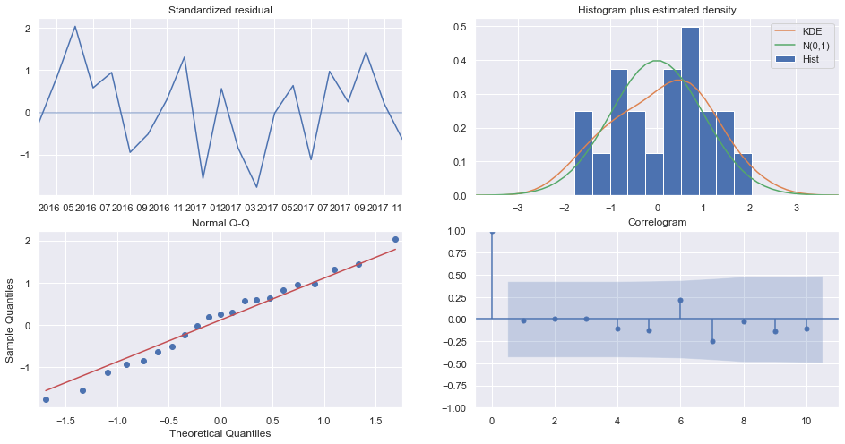

```python
results.plot_diagnostics(figsize=(16, 8))
plt.show()
```

|  | **The model diagnostics indicates that the model residuals are near normally distributed** |
| --- | --- |